# PS9

Jamie Duncan

27/11/2020

#### Section 1

##### Question 1: How many different women are in the data? How many observations per year? We will refer to each row as a ‘person-year observation’ since the row contains data on a given person in a particular year. In a few sentences, describe one advantage and one disadvantage of using a contemporary cohort of women rather than an older cohort in estimating the predictors of the mother wage gap.

```r
length(unique(mom.money$PUBID))
```

```
## [1] 1569
```

There are 1569 women featured in the panel data

```r
summary(as.factor(mom.money$year))
```

```
## 1997 1998 1999 2000 2001 2002 2003 2004 2005 2006 2007 2008 2009 2010 2011 2013
##  374  803 1042 1189 1239 1293 1267 1257 1259 1284 1267 1263 1231 1173 1157 1184
```

```r
median(summary(as.factor(mom.money$year)))
```

```
## [1] 1235
```

```r
mean(summary(as.factor(mom.money$year)))
```

```
## [1] 1142.625
```

The number of observations per year ranges between a minimum of 374 in 1997 to a maximum of 1293 in 2002. The median number of observations per year is 1235 and the average number of observations is 1142.6. One advantage of using a contemporary cohort approach is that the trends are as current as possible. A disadvantage is that long-term effects may be missed with a contemporary cohort.

##### Question 2: `numChildren` is the variable representing how many children the woman had at the time of an observation. Please provide a table that shows the proportion of observations by the number of children. Provide a brief substantive interpretation of the results.

```r
numChild <- as.data.frame(round(prop.table(table(mom.money$numChildren)), 4))
numChild[,1] <- as.numeric(numChild[,1])
numChild
```

```
##   Var1   Freq
## 1    1 0.6442
## 2    2 0.1825
## 3    3 0.1153
## 4    4 0.0441
## 5    5 0.0114
## 6    6 0.0015
## 7    7 0.0006
## 8    8 0.0002
## 9    9 0.0001
```

64% of the observations indicate that the participants have no children. A further 18% of respondents have 1 child, 12% have 2 children and 4% have 3 children at the the times of response. 1 percent or fewer women have 4 or more children. This downward trend is visualized below.

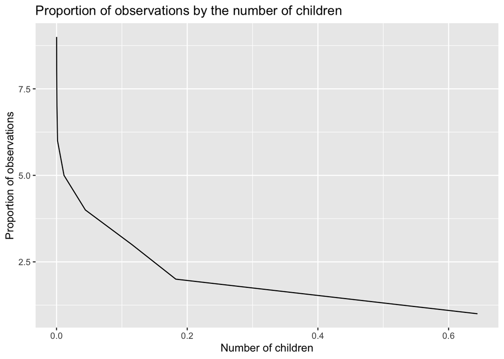

```r
ggplot(numChild, aes(x = Freq, y = Var1))+
  geom_line()+
  labs(title = "Proportion of observations by the number of children")+
  xlab("Number of children")+
  ylab("Proportion of observations")
```

##### Question 3: Create a new indicator variable `isMother` that takes a value of 1 if the woman has at least one child in that year and a value of 0 otherwise. Tabulate the new variable. Briefly comment on the results.

```r
mom.money <- mom.money %>%
  mutate(isMother = if_else(numChildren >= 1, 1, 0))

mean(mom.money$isMother, na.rm = T)
```

```
## [1] 0.3557782
```

`isMother` has a mean of 0.36 which is consistent with the finding above that 64% of observed women are not mothers.

##### Question 4: Create a new variable called `logwage` that is the log of `wage`. Make two boxplots, one for `wage` and the other for `logwage`, as a function of educational level (`educ`). Compare the two boxplots and discuss the purpose of the log transformation.

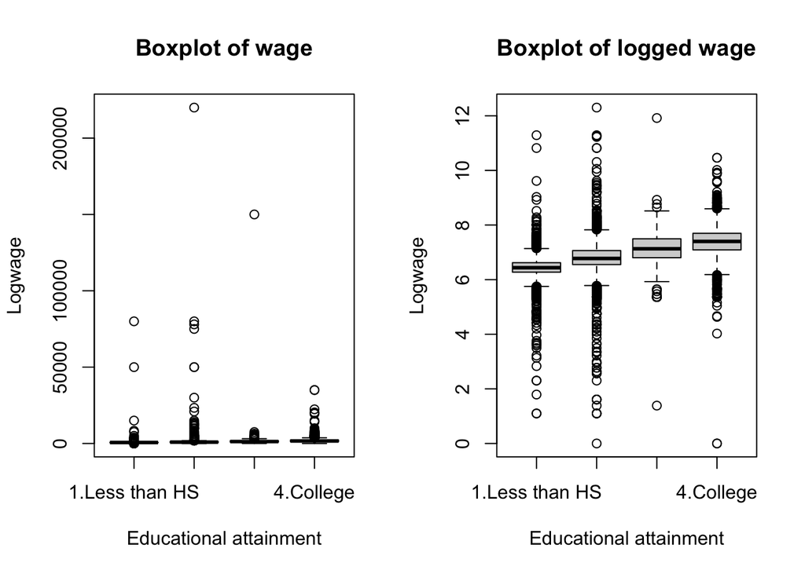

```r
mom.money <- mom.money %>%
  mutate(logwage = log(wage))

par(mfrow = c(1, 2))
boxplot(mom.money$wage ~ mom.money$educ, main = "Boxplot of wage", ylab= "Logwage", xlab = "Educational attainment")
boxplot(mom.money$logwage~ mom.money$educ, main = "Boxplot of logged wage", ylab= "Logwage", xlab = "Educational attainment")
```

The boxplot for wage (unlogged) is heavily skewed by outlier high earning women. This obscures real variations among the wages of more typical research participants. By logging the data (as in the boxplot on the right) we can see that the skew from the outlier income has been smoothed out to allow us to see the differences that exist among lower earners. This reveals an unserprising thrend that a participants’ typical income increases with higher levels of education.

##### Question 5: In the same graph, plot the mean `logwage` against year for mothers, then for non-mothers in a different color or line type. Include a legend and a proper title. Make sure the figure and axes are clearly labeled. Give a brief interpretation of the results.

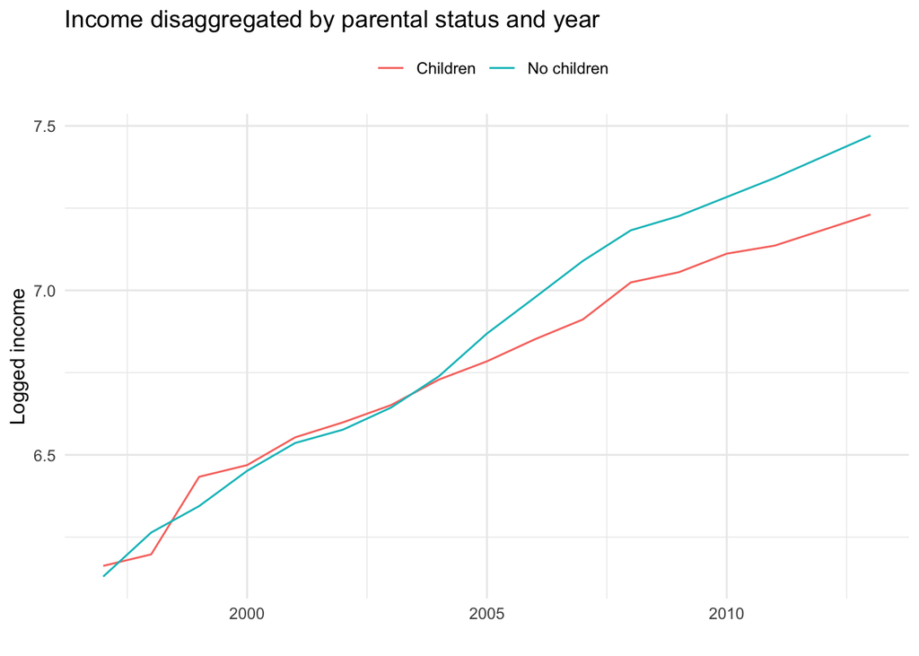

```r
mom.money %>%
  select(logwage, isMother, year) %>%
  group_by(isMother, year) %>%
  summarise(m.logwage = mean(logwage)) %>%
  mutate(isMother = recode(isMother, "0" = "No children", "1" = "Children")) %>%
  filter(!isMother == "NA") %>%
  ggplot(aes(x = year, y = m.logwage, group = isMother, colour = factor(isMother)))+
  geom_line()+
  theme_minimal()+
  theme(legend.title = element_blank(), legend.position = "top")+
  labs(title = "Income disaggregated by parental status and year",
       y = "Logged income",
       x = "")
```

While women with and without children start with very similar incomes, over time those without children earn higher incomes than those with children.

##### Question 6: Run a regression using fixed effects for both `woman` and `year`. You should be sure to include variables for number of children (`numChildren`) and job characteristics (`fullTime`, `firmSize`, `multipleLocations`, `unionized`, `industry`). Note: that you should not use the `isMother` variable you created earlier in this model. Report the coefficient of `numChildren`. Provide a brief substantive interpretation of this coefficient and the coefficients for any two other variables.

```r
fixfit <- plm(logwage ~ numChildren + fullTime + firmSize + multipleLocations + unionized + industry + factor(year), data = mom.money, index=c("PUBID"), model="within")
summary(fixfit)
```

```
## Oneway (individual) effect Within Model
##
## Call:
## plm(formula = logwage ~ numChildren + fullTime + firmSize + multipleLocations +
##     unionized + industry + factor(year), data = mom.money, model = "within",
##     index = c("PUBID"))
##
## Unbalanced Panel: n = 1546, T = 1-16, N = 12329
##
## Residuals:
##       Min.    1st Qu.     Median    3rd Qu.       Max.
## -6.2349972 -0.1364510  0.0060339  0.1472810  4.5270338
##
## Coefficients:
##                                                                                               Estimate
## numChildren                                                                                 -0.0475771
## fullTimeTRUE                                                                                 0.1546855
## firmSize2. 30-299                                                                            0.0072912
## firmSize3. 300+                                                                              0.1005815
## multipleLocations                                                                            0.0704676
## unionized                                                                                    0.0985191
## industryArts, Entertainment, Recreation, Accommodations, and Food Services                  -0.1350842
## industryConstruction                                                                         0.2259525
## industryEducational and Social Services                                                      0.1065296
## industryFinance, Insurance, Real Estate, and Rental and Leasing                              0.1774449
## industryHealth Care                                                                          0.1623685
## industryInformation and Communications                                                       0.1087910
## industryManufacturing - Durable Goods                                                        0.2088564
## industryManufacturing - Nondurable Goods                                                     0.1866347
## industryMining                                                                               0.5914173
## industryOther                                                                                0.0961322
## industryOther Services                                                                       0.1282649
## industryProfessional, Scientific, Management, Administrative, and Waste Management Services  0.2194325
## industryPublic Administration and Armed Forces                                               0.2134406
## industryRetail Trade                                                                         0.0300359
## industryTransportation and Warehousing                                                       0.0937880
## industryUtilities                                                                            0.2268789
## industryWholesale Trade                                                                      0.2148753
## factor(year)1998                                                                             0.0791531
## factor(year)1999                                                                             0.1537709
```

[output cut: 162 more lines]

```
## factor(year)2006                                                                            ***
## factor(year)2007                                                                            ***
## factor(year)2008                                                                            ***
## factor(year)2009                                                                            ***
## factor(year)2010                                                                            ***
## factor(year)2011                                                                            ***
## factor(year)2013                                                                            ***
## ---
## Signif. codes:  0 '***' 0.001 '**' 0.01 '*' 0.05 '.' 0.1 ' ' 1
##
## Total Sum of Squares:    2990.7
## Residual Sum of Squares: 1620.7
## R-Squared:      0.4581
## Adj. R-Squared: 0.37826
## F-statistic: 239.036 on 38 and 10745 DF, p-value: < 2.22e-16
```

##### Question 7: Add interactions between `numChildren` and `regularity` and between `numChildren` and `hazardous` to the model in the previous question. Report the five coefficients involving these variables. Interpret the interaction term for numChldren and hazardous. Can we interpret the effect of occupation characteristics on motherhood wage penalty as causal? Why or why not?

```r
fixfit2 <- plm(logwage ~ numChildren * regularity * hazardous + fullTime + firmSize + multipleLocations + unionized + industry + factor(year), data = mom.money, index=c("PUBID", "year"), model="within")
summary(fixfit2)
```

```
## Oneway (individual) effect Within Model
##
## Call:
## plm(formula = logwage ~ numChildren * regularity * hazardous +
##     fullTime + firmSize + multipleLocations + unionized + industry +
##     factor(year), data = mom.money, model = "within", index = c("PUBID",
##     "year"))
##
## Unbalanced Panel: n = 1546, T = 1-16, N = 12155
##
## Residuals:
##       Min.    1st Qu.     Median    3rd Qu.       Max.
## -5.9421592 -0.1341390  0.0052988  0.1450862  4.5068129
##
## Coefficients:
##                                                                                               Estimate
## numChildren                                                                                  0.1972800
## regularity                                                                                  -0.0120598
## hazardous                                                                                    0.0690894
## fullTimeTRUE                                                                                 0.1470089
## firmSize2. 30-299                                                                            0.0019834
## firmSize3. 300+                                                                              0.1026577
## multipleLocations                                                                            0.0679624
## unionized                                                                                    0.0951157
## industryArts, Entertainment, Recreation, Accommodations, and Food Services                  -0.0921316
## industryConstruction                                                                         0.2445310
## industryEducational and Social Services                                                      0.1441700
## industryFinance, Insurance, Real Estate, and Rental and Leasing                              0.2241326
## industryHealth Care                                                                          0.1900696
## industryInformation and Communications                                                       0.1659214
## industryManufacturing - Durable Goods                                                        0.2178786
## industryManufacturing - Nondurable Goods                                                     0.2024658
## industryMining                                                                               0.6557530
## industryOther                                                                                0.2203833
## industryOther Services                                                                       0.1606743
## industryProfessional, Scientific, Management, Administrative, and Waste Management Services  0.2538515
## industryPublic Administration and Armed Forces                                               0.2772756
## industryRetail Trade                                                                         0.0723360
## industryTransportation and Warehousing                                                       0.1241011
## industryUtilities                                                                            0.2638135
```

[output cut: 193 more lines]

```
## factor(year)2010                                                                            ***
## factor(year)2011                                                                            ***
## factor(year)2013                                                                            ***
## numChildren:regularity                                                                      *
## numChildren:hazardous                                                                       *
## regularity:hazardous
## numChildren:regularity:hazardous                                                            .
## ---
## Signif. codes:  0 '***' 0.001 '**' 0.01 '*' 0.05 '.' 0.1 ' ' 1
##
## Total Sum of Squares:    2899.2
## Residual Sum of Squares: 1535.4
## R-Squared:      0.4704
## Adj. R-Squared: 0.39075
## F-statistic: 213.276 on 44 and 10565 DF, p-value: < 2.22e-16
```

The interaction model explains away a lot of the significance in the number of children coefficient. We now have a coefficient of 0.2 but at 0.1 significance, which probably wouldn’t be worth reporting in an academic paper as an interesting finding. Regarding he interaction terms, we see that on their own, hazardousness and regularity of work produce no significant effect. Regularity interacted with number of children produces a coefficient of -0.19, while hazardous work interacted with number of children produces -0.14. Both are modestly significant at 0.05. The number of children interacted with both regularity and hazardous produces a coefficient of 0.1 with weak significance at 0.1. The interaction effects show that there is a type of woman in the data set that both has more children and higher income; that individual will more likely have regular and more hazardous work. This insight is not very significant so it would require additional inquiry to determine the qualities of this type of person.

##### Question 8: Compare and interpret the adjusted R2 of the linear models in Question 6 and Question 7. If we wanted to predict the wage an out-of-sample person-year observation, which model would we prefer to use?

The adjusted $R^2$ for the first model is 0.38 and the adjusted $R^2$ for the second model is 0.39. Typically the higher the $R^2$ is associated with a more accurate model. On this basis I conclude that the second model is the closest fit and thus the model that I would prefer to use.

#### Section 2

```r
bk16 <- read.csv("broockman_kalla_2016.csv")
```

##### Question 1: First, load broockman_kalla_2016.csv into R and explore the data. How many observations are there? This file includes all of the people that the researchers attempted to contact. As we’ve learned, experiments also experience this noncompliance. However, many of these people did not even respond to the baseline survey before the experiment was conducted. As such, we are not be able to estimate how the treatment changed these individuals’ attitudes, since we don’t know where they were to begin with. To deal with these people who were never reached, subset your data so that you are only looking at people who have a valid (non-NA) answer for therm_trans_t0, which was collected in the pre-treatment baseline study. How many observations are you left with? How many are assigned to treatment? Placebo? What do these numbers tell us about the randomization process? You should use this subset for the rest of this questions in this part of the exam.

```r
summary(bk16)
```

```
##        X             vf_age      vf_racename          vf_female
##  Min.   :    1   Min.   : 16.0   Length:68378       Min.   :0.000
##  1st Qu.:17095   1st Qu.: 33.0   Class :character   1st Qu.:0.000
##  Median :34190   Median : 49.0   Mode  :character   Median :1.000
##  Mean   :34190   Mean   : 49.2                      Mean   :0.564
##  3rd Qu.:51284   3rd Qu.: 63.0                      3rd Qu.:1.000
##  Max.   :68378   Max.   :106.0                      Max.   :1.000
##                  NA's   :29367
##   vf_democrat     miami_trans_law_t0 therm_trans_t0   respondent_t0
##  Min.   :0.0000   Min.   :-3.0       Min.   :  0.00   Min.   :0.00000
##  1st Qu.:0.0000   1st Qu.: 0.0       1st Qu.: 49.00   1st Qu.:0.00000
##  Median :0.0000   Median : 2.0       Median : 50.00   Median :0.00000
##  Mean   :0.4522   Mean   : 1.5       Mean   : 53.28   Mean   :0.02669
##  3rd Qu.:1.0000   3rd Qu.: 3.0       3rd Qu.: 73.00   3rd Qu.:0.00000
##  Max.   :1.0000   Max.   : 3.0       Max.   :100.00   Max.   :1.00000
##                   NA's   :66553      NA's   :66553
##  miami_trans_law_t1 therm_trans_t1   respondent_t1   miami_trans_law_t2
##  Min.   :-3.00      Min.   :  0.00   Min.   :0.00    Min.   :-3.00
##  1st Qu.: 0.00      1st Qu.: 50.00   1st Qu.:0.00    1st Qu.: 0.00
##  Median : 2.00      Median : 50.00   Median :0.00    Median : 2.00
##  Mean   : 1.51      Mean   : 57.33   Mean   :0.33    Mean   : 1.46
##  3rd Qu.: 3.00      3rd Qu.: 82.00   3rd Qu.:1.00    3rd Qu.: 3.00
##  Max.   : 3.00      Max.   :100.00   Max.   :1.00    Max.   : 3.00
##  NA's   :67778      NA's   :67778    NA's   :66553   NA's   :67810
##  therm_trans_t2   respondent_t2   therm_trans_t3   respondent_t3
##  Min.   :  0.00   Min.   :0.00    Min.   :  0.00   Min.   :0.00
##  1st Qu.: 50.00   1st Qu.:0.00    1st Qu.: 50.00   1st Qu.:0.00
##  Median : 50.00   Median :0.00    Median : 50.00   Median :0.00
##  Mean   : 56.83   Mean   :0.31    Mean   : 55.58   Mean   :0.31
##  3rd Qu.: 80.00   3rd Qu.:1.00    3rd Qu.: 78.00   3rd Qu.:1.00
##  Max.   :100.00   Max.   :1.00    Max.   :100.00   Max.   :1.00
##  NA's   :67810    NA's   :66553   NA's   :67811    NA's   :66553
##  therm_trans_t4   respondent_t4   exp_actual_convo     treat_ind
##  Min.   :  0.00   Min.   :0.00    Length:68378       Min.   :0.0
##  1st Qu.: 50.00   1st Qu.:0.00    Class :character   1st Qu.:0.0
##  Median : 50.00   Median :0.00    Mode  :character   Median :0.0
##  Mean   : 55.89   Mean   :0.21                       Mean   :0.5
##  3rd Qu.: 78.00   3rd Qu.:0.00                       3rd Qu.:1.0
##  Max.   :100.00   Max.   :1.00                       Max.   :1.0
##  NA's   :67993    NA's   :66553                      NA's   :66553
##  canvasser_trans  canvasser_id      hh_id
##  Min.   :0.00    Min.   : 1.00   Length:68378
##  1st Qu.:0.00    1st Qu.:13.50   Class :character
##  Median :0.00    Median :31.00   Mode  :character
##  Mean   :0.35    Mean   :28.79
##  3rd Qu.:1.00    3rd Qu.:44.00
##  Max.   :1.00    Max.   :56.00
##  NA's   :67891   NA's   :67891
```

There are 68378 observations in the data set, although a large majority are incomplete cases (meaning there are NAs)

```r
bk.t0 <- bk16 %>%
  filter(therm_trans_t0 >= 0)
length(bk.t0$therm_trans_t0)
```

```
## [1] 1825
```

```r
summary(bk.t0)
```

```
##        X             vf_age      vf_racename          vf_female
##  Min.   :66554   Min.   :16.00   Length:1825        Min.   :0.0000
##  1st Qu.:67010   1st Qu.:31.00   Class :character   1st Qu.:0.0000
##  Median :67466   Median :49.00   Mode  :character   Median :1.0000
##  Mean   :67466   Mean   :46.96                      Mean   :0.5874
##  3rd Qu.:67922   3rd Qu.:61.00                      3rd Qu.:1.0000
##  Max.   :68378   Max.   :97.00                      Max.   :1.0000
##                  NA's   :3
##   vf_democrat     miami_trans_law_t0 therm_trans_t0   respondent_t0
##  Min.   :0.0000   Min.   :-3.000     Min.   :  0.00   Min.   :1
##  1st Qu.:0.0000   1st Qu.: 0.000     1st Qu.: 49.00   1st Qu.:1
##  Median :0.0000   Median : 2.000     Median : 50.00   Median :1
##  Mean   :0.4756   Mean   : 1.503     Mean   : 53.28   Mean   :1
##  3rd Qu.:1.0000   3rd Qu.: 3.000     3rd Qu.: 73.00   3rd Qu.:1
##  Max.   :1.0000   Max.   : 3.000     Max.   :100.00   Max.   :1
##
##  miami_trans_law_t1 therm_trans_t1   respondent_t1    miami_trans_law_t2
##  Min.   :-3.000     Min.   :  0.00   Min.   :0.0000   Min.   :-3.00
##  1st Qu.: 0.000     1st Qu.: 50.00   1st Qu.:0.0000   1st Qu.: 0.00
##  Median : 2.000     Median : 50.00   Median :0.0000   Median : 2.00
##  Mean   : 1.515     Mean   : 57.33   Mean   :0.3288   Mean   : 1.46
##  3rd Qu.: 3.000     3rd Qu.: 82.00   3rd Qu.:1.0000   3rd Qu.: 3.00
##  Max.   : 3.000     Max.   :100.00   Max.   :1.0000   Max.   : 3.00
##  NA's   :1225       NA's   :1225                      NA's   :1257
##  therm_trans_t2   respondent_t2    therm_trans_t3   respondent_t3
##  Min.   :  0.00   Min.   :0.0000   Min.   :  0.00   Min.   :0.0000
##  1st Qu.: 50.00   1st Qu.:0.0000   1st Qu.: 50.00   1st Qu.:0.0000
##  Median : 50.00   Median :0.0000   Median : 50.00   Median :0.0000
##  Mean   : 56.83   Mean   :0.3112   Mean   : 55.58   Mean   :0.3107
##  3rd Qu.: 80.00   3rd Qu.:1.0000   3rd Qu.: 78.00   3rd Qu.:1.0000
##  Max.   :100.00   Max.   :1.0000   Max.   :100.00   Max.   :1.0000
##  NA's   :1257                      NA's   :1258
##  therm_trans_t4   respondent_t4   exp_actual_convo     treat_ind
##  Min.   :  0.00   Min.   :0.000   Length:1825        Min.   :0.0000
##  1st Qu.: 50.00   1st Qu.:0.000   Class :character   1st Qu.:0.0000
##  Median : 50.00   Median :0.000   Mode  :character   Median :0.0000
##  Mean   : 55.89   Mean   :0.211                      Mean   :0.4997
##  3rd Qu.: 78.00   3rd Qu.:0.000                      3rd Qu.:1.0000
##  Max.   :100.00   Max.   :1.000                      Max.   :1.0000
##  NA's   :1440
##  canvasser_trans   canvasser_id      hh_id
##  Min.   :0.0000   Min.   : 1.00   Length:1825
##  1st Qu.:0.0000   1st Qu.:13.50   Class :character
##  Median :0.0000   Median :31.00   Mode  :character
##  Mean   :0.3491   Mean   :28.79
##  3rd Qu.:1.0000   3rd Qu.:44.00
##  Max.   :1.0000   Max.   :56.00
##  NA's   :1338     NA's   :1338
```

There are 1825 entries for `therm_trans_t0`. Treatment is split evenly with a mean of 0.5 for participants both treated and non-treated, which indicates participants were randomized effectively though we can check that more precisely.

```r
bk.t0 %>%
  group_by(treat_ind) %>%
  summarise(median(vf_age, na.rm = T), mean(vf_democrat), mean(vf_female))
```

```
## # A tibble: 2 x 4
##   treat_ind `median(vf_age, na.rm = T)` `mean(vf_democrat)` `mean(vf_female)`
##       <int>                       <dbl>               <dbl>             <dbl>
## 1         0                          47               0.463             0.593
## 2         1                          50               0.488             0.582
```

```r
"Treated"
```

```
## [1] "Treated"
```

```r
prop.table(summary(factor(bk.t0$vf_racename[bk.t0$treat_ind == 1])))
```

```
## African American            Asian        Caucasian         Hispanic
##      0.254385965      0.008771930      0.217105263      0.517543860
##  Native American          Unknown
##      0.001096491      0.001096491
```

```r
"Control"
```

```
## [1] "Control"
```

```r
prop.table(summary(factor(bk.t0$vf_racename[bk.t0$treat_ind == 0])))
```

```
## African American            Asian        Caucasian         Hispanic
##      0.254107338      0.005476451      0.209200438      0.530120482
##  Native American
##      0.001095290
```

The distribution of participants by race is more even between the treatment and control groups.

##### Question 2: To examine the effect of these conversations, Broockman and Kalla compared how people in the treatment and placebo groups evaluated transgender people on a specific type of survey question called a “feeling thermometer,” where respondents indicate where their feelings fall on a scale of 0 (very cold) to 100 (very warm). Further, to measure whether the changes persisted, Broockman and Kalla also conducted follow-up surveys up to 3 months after the original treatment. Thus, Brookman and Kalla’s study required reaching participants in multiple ways: both for a face-to-face interaction where the treatment would be delivered and through multiple follow-up surveys where the long-term effects of the treatment could be measured. We would like to further check that noncompliance did not meaningfully affect our randomization, since the basis of calculating our treatment effect depends on this. To do this, we can conduct a placebo test to ensure that the average level of support (our outcome) is not meaningfully different between the treatment and control groups before treatment was administered (during the baseline survey). Conduct a t-test on support before treatment was administered (t = 0) between the treatment and control groups among the subset of people you calculated in question 1. Construct a 95% confidence interval around your estimate. If the null hypothesis is no difference between the two groups, can you reject the null hypothesis?

```r
therm.tt <- t.test(therm_trans_t0 ~ treat_ind, data = bk.t0)
therm.tt
```

```
##
##  Welch Two Sample t-test
##
## data:  therm_trans_t0 by treat_ind
## t = -0.48489, df = 1822.9, p-value = 0.6278
## alternative hypothesis: true difference in means is not equal to 0
## 95 percent confidence interval:
##  -3.351838  2.023001
## sample estimates:
## mean in group 0 mean in group 1
##        52.94962        53.61404
```

The 95% confidence interval straddles zero meaning that I cannot reject the null hypothesis.

```r
diff(therm.tt$estimate)
```

```
## mean in group 1
##       0.6644184
```

The difference in means is about 0.66.

##### Question 3: To simplify our analysis, we will focus on the average treatment effects among the treated (ATT). Kalla and Broockman experienced noncompliance in their study, where individuals assigned to the treatment group refused to engage in conversations with canvassers. Because accounting for this noncompliance statistically is beyond the scope of this class, we will look only at the cases where treatment was actually delivered. In contrast, Broockman and Kalla estimate the average treatment effect of compliers (adjusting for compliance rates). They also include many covariates; we will only include a few. For these reasons and others, our estimates may differ slightly. Next, let’s see if the attitudes in the treatment and placebo changed after the treatment was administered and for how long these differences lasted. Perform four difference-in-means calculations—one for each wave (t = 1, 2, 3, 4). When performing each test, remove any NAs in that wave. (These NAs might arise from participants failing to complete different waves of the surveys—a process that social scientists call attrition—or for other reasons.) For example, for wave 1, use all cases that don’t have missing outcome data in wave 1, and in wave 2, use all cases that don’t have missing outcome data in wave 2 (in the t.test() function, you can accomplish this with the na.action = na.omit argument). Construct 95% confidence intervals for your estimates. At each stage, do we reject or retain the null hypothesis that no difference between the two groups exists? You are welcome to use t.test() to calculate these differences and the confidence intervals, but pick one comparison and calculate the estimates by hand (the techniques in Section 7.1 of QSS may be helpful).

```r
tt1 <- t.test(therm_trans_t1 ~ treat_ind, data = bk.t0, na.action = na.omit)
tt2 <- t.test(therm_trans_t2 ~ treat_ind, data = bk.t0, na.action = na.omit)
tt3 <- t.test(therm_trans_t3 ~ treat_ind, data = bk.t0, na.action = na.omit)
tt4 <- t.test(therm_trans_t4 ~ treat_ind, data = bk.t0, na.action = na.omit)
```

```r
tt1
```

```
##
##  Welch Two Sample t-test
##
## data:  therm_trans_t1 by treat_ind
## t = -2.9164, df = 568.86, p-value = 0.00368
## alternative hypothesis: true difference in means is not equal to 0
## 95 percent confidence interval:
##  -11.305629  -2.205931
## sample estimates:
## mean in group 0 mean in group 1
##        54.05178        60.80756
```

```r
diff(tt1$estimate)
```

```
## mean in group 1
##         6.75578
```

For treatment wave 1, the t.test indicates that there are significant results. The p value indicates significance at 0.01 and zero does not fall within the confidence intervals. The estimated average treatment effect is 6.8%.

```r
tt2
```

```
##
##  Welch Two Sample t-test
##
## data:  therm_trans_t2 by treat_ind
## t = -1.9, df = 564.04, p-value = 0.05795
## alternative hypothesis: true difference in means is not equal to 0
## 95 percent confidence interval:
##  -9.1286473  0.1517094
## sample estimates:
## mean in group 0 mean in group 1
##        54.57447        59.06294
```

```r
diff(tt2$estimate)
```

```
## mean in group 1
##        4.488469
```

For treatment wave 2, zero is included in the confidence intervals so we cannot reject the null hypothesis. The p-value would indicate significance at 0.1. The estimated treatment effect is 4.49%

```r
tt3
```

```
##
##  Welch Two Sample t-test
##
## data:  therm_trans_t3 by treat_ind
## t = -2.7234, df = 559.97, p-value = 0.006662
## alternative hypothesis: true difference in means is not equal to 0
## 95 percent confidence interval:
##  -10.724053  -1.736922
## sample estimates:
## mean in group 0 mean in group 1
##        52.50523        58.73571
```

```r
diff(tt3$estimate)
```

```
## mean in group 1
##        6.230488
```

For treatment wave 3, we see a p-value of less than 0.01 and confidence intervals that no not include zero so we can reject the null hypothesis and conclude that the average treatment effect of 6.23 is significant.

```r
tt4
```

```
##
##  Welch Two Sample t-test
##
## data:  therm_trans_t4 by treat_ind
## t = -1.9044, df = 371.67, p-value = 0.05762
## alternative hypothesis: true difference in means is not equal to 0
## 95 percent confidence interval:
##  -10.770451   0.172306
## sample estimates:
## mean in group 0 mean in group 1
##        53.42718        58.72626
```

```r
diff(tt4$estimate)
```

```
## mean in group 1
##        5.299073
```

For treatment wave 4, we see a p-value of less than 0.1 and confidence intervals that include zero, meaning we cannot reject the null hypothesis and attribute significance to the estimated treatment effect of 5.3%.

```r
mu1 <- mean(bk.t0$therm_trans_t3, na.rm = T)
mu2 <- mean(bk.t0$treat_ind, na.rm = T)
sd1 <- sd(bk.t0$therm_trans_t3, na.rm = T)
sd2 <- sd(bk.t0$treat_ind, na.rm = T)
n1 <- length(bk.t0$therm_trans_t3)
n2 <- length(bk.t0$treat_ind)
se <- sqrt(sd1*sd1/n1+sd2*sd2/n2)
err <- qt(0.975,df=pmin(n1,n2)-1)*se


lower <- (mu1-mu2)-err
upper <- (mu1-mu2)+err
lower
```

```
## [1] 53.82572
```

```r
upper
```

```
## [1] 56.33885
```

##### Question 4:Let’s focus on the difference-in-means test at time t = 1. If the null hypothesis is that there is no difference between the groups, what would it mean to make a type I error? What would it mean to make a type II error? If we did something to increase the statistical power of the study, would we increase or decrease the probability of a type II error?

To make a type 1 error would be to erroneously reject the null hypothesis that there is no difference between the groups. To make a type II error would be to fail to reject the null hypothesis when it is correct. Increasing the power of the study decreases the likelihood of a type II error.

##### Question 5: Finally, let’s approximate the estimation strategy used by Broockman and Kalla in their analysis. To estimate the average treatment effect, they use a regression framework. Regress the feeling thermometer dependent variable (measure at time t = 3) on treatment assignment. To further alleviate concerns of imbalances between treatment and control groups, adjust for an individual’s feeling thermometer scores at time t = 0, her age, gender, race, and political party. Further, to account for possible differences between the more than 50 canvassers, please include in your model a fixed effect (i.e., dummy variable) for each canvasser. What is the estimated treatment effect (be sure to mention units)? Is this estimate statistically significant at the 0.05 level? Conduct the same analysis for surveys three months after treatment (t = 4) and compare the effects and statistical significance. Provide a substantive interpretation of the results.

```r
summary(lm(therm_trans_t3 ~ treat_ind + therm_trans_t0 + vf_age + vf_racename + vf_female + vf_democrat + factor(canvasser_id), data = bk.t0))
```

```
##
## Call:
## lm(formula = therm_trans_t3 ~ treat_ind + therm_trans_t0 + vf_age +
##     vf_racename + vf_female + vf_democrat + factor(canvasser_id),
##     data = bk.t0)
##
## Residuals:
##     Min      1Q  Median      3Q     Max
## -55.221 -10.050  -0.223   9.071  78.142
##
## Coefficients:
##                         Estimate Std. Error t value Pr(>|t|)
## (Intercept)             27.82415   12.53682   2.219  0.02714 *
## treat_ind                5.72587    2.16235   2.648  0.00848 **
## therm_trans_t0           0.60871    0.04038  15.076  < 2e-16 ***
## vf_age                  -0.14653    0.06877  -2.131  0.03384 *
## vf_racenameAsian        15.61608   12.24680   1.275  0.20316
## vf_racenameCaucasian     4.45887    3.98614   1.119  0.26412
## vf_racenameHispanic      3.85934    3.43961   1.122  0.26266
## vf_female                5.78262    2.22011   2.605  0.00961 **
## vf_democrat              2.24058    2.47712   0.905  0.36638
## factor(canvasser_id)2  -12.80378   13.43151  -0.953  0.34115
## factor(canvasser_id)3   -8.18123   13.82315  -0.592  0.55435
## factor(canvasser_id)4  -12.83483   12.40667  -1.035  0.30165
## factor(canvasser_id)5   -6.58821   12.55680  -0.525  0.60016
## factor(canvasser_id)6    2.58312   13.78436   0.187  0.85147
## factor(canvasser_id)7  -11.19595   18.31853  -0.611  0.54150
## factor(canvasser_id)8   -8.61693   12.35697  -0.697  0.48608
## factor(canvasser_id)9  -16.68449   16.42500  -1.016  0.31046
## factor(canvasser_id)10 -23.10029   18.14525  -1.273  0.20388
## factor(canvasser_id)11  14.49494   23.00829   0.630  0.52914
## factor(canvasser_id)12   4.36242   22.58611   0.193  0.84696
## factor(canvasser_id)13  -7.11176   15.41529  -0.461  0.64485
## factor(canvasser_id)14  -9.55663   12.91529  -0.740  0.45985
## factor(canvasser_id)15 -49.49333   18.10440  -2.734  0.00660 **
## factor(canvasser_id)16   1.55882   15.26688   0.102  0.91874
## factor(canvasser_id)17 -20.62140   15.36513  -1.342  0.18048
## factor(canvasser_id)18  19.80292   22.79805   0.869  0.38568
## factor(canvasser_id)19  -3.17007   12.69017  -0.250  0.80289
## factor(canvasser_id)20   6.06910   14.64836   0.414  0.67891
```

[output cut: 26 more lines]

```
## factor(canvasser_id)49  -8.24025   12.80451  -0.644  0.52032
## factor(canvasser_id)50  -2.88157   14.76439  -0.195  0.84538
## factor(canvasser_id)51   1.34668   13.56017   0.099  0.92095
## factor(canvasser_id)52 -11.11579   12.57676  -0.884  0.37742
## factor(canvasser_id)53  -3.29082   18.21361  -0.181  0.85673
## factor(canvasser_id)54  -7.08443   16.34065  -0.434  0.66490
## factor(canvasser_id)55   2.97081   14.52154   0.205  0.83803
## factor(canvasser_id)56  -1.96280   13.34512  -0.147  0.88316
## ---
## Signif. codes:  0 '***' 0.001 '**' 0.01 '*' 0.05 '.' 0.1 ' ' 1
##
## Residual standard error: 19.5 on 332 degrees of freedom
##   (1431 observations deleted due to missingness)
## Multiple R-squared:  0.5413, Adjusted R-squared:  0.4571
## F-statistic: 6.423 on 61 and 332 DF,  p-value: < 2.2e-16
```

The treatment effect when taking into account the range of variables asked for is 5.73, which is slightly lower than the treatment effect of 6.23 calculated above with a t-test. The estimate is significant at the 0.01 level.

```r
summary(lm(therm_trans_t4 ~ treat_ind + therm_trans_t0 + vf_age + vf_racename + vf_female + vf_democrat + factor(canvasser_id), data = bk.t0))
```

```
##
## Call:
## lm(formula = therm_trans_t4 ~ treat_ind + therm_trans_t0 + vf_age +
##     vf_racename + vf_female + vf_democrat + factor(canvasser_id),
##     data = bk.t0)
##
## Residuals:
##    Min     1Q Median     3Q    Max
## -55.48 -10.07  -0.20  10.24  51.07
##
## Coefficients:
##                         Estimate Std. Error t value Pr(>|t|)
## (Intercept)             28.67281   10.36111   2.767  0.00599 **
## treat_ind                4.51476    2.30751   1.957  0.05130 .
## therm_trans_t0           0.65616    0.04287  15.304  < 2e-16 ***
## vf_age                  -0.03560    0.07188  -0.495  0.62080
## vf_racenameAsian        -7.99270   12.72814  -0.628  0.53050
## vf_racenameCaucasian    -0.60572    4.10724  -0.147  0.88285
## vf_racenameHispanic     -2.17873    3.58886  -0.607  0.54424
## vf_female                3.49229    2.34967   1.486  0.13822
## vf_democrat              0.38190    2.59292   0.147  0.88300
## factor(canvasser_id)2  -32.57760   11.86439  -2.746  0.00639 **
## factor(canvasser_id)3   -8.17730   12.11938  -0.675  0.50035
## factor(canvasser_id)4  -17.27679   10.39594  -1.662  0.09755 .
## factor(canvasser_id)5   -6.80529   10.39528  -0.655  0.51318
## factor(canvasser_id)6   -8.17502   12.07019  -0.677  0.49873
## factor(canvasser_id)7    1.48855   17.25695   0.086  0.93132
## factor(canvasser_id)8   -9.91062   10.40580  -0.952  0.34163
## factor(canvasser_id)9   -0.28181   17.22547  -0.016  0.98696
## factor(canvasser_id)10 -18.68666   17.08214  -1.094  0.27484
## factor(canvasser_id)11  -1.54314   22.33757  -0.069  0.94497
## factor(canvasser_id)12  29.74527   21.92584   1.357  0.17589
## factor(canvasser_id)13  19.52045   15.14513   1.289  0.19840
## factor(canvasser_id)14  -8.06592   11.11685  -0.726  0.46866
## factor(canvasser_id)15 -11.28963   17.07325  -0.661  0.50895
## factor(canvasser_id)16   7.20024   15.01114   0.480  0.63181
## factor(canvasser_id)17  -9.63452   13.92911  -0.692  0.48965
## factor(canvasser_id)18  34.65840   22.18902   1.562  0.11932
## factor(canvasser_id)19  -5.85545   10.69360  -0.548  0.58438
## factor(canvasser_id)20  -9.10462   13.11025  -0.694  0.48791
```

[output cut: 28 more lines]

```
## factor(canvasser_id)49  -2.39979   10.84487  -0.221  0.82502
## factor(canvasser_id)50  -0.50614   12.66727  -0.040  0.96815
## factor(canvasser_id)51   6.80286   12.09005   0.563  0.57406
## factor(canvasser_id)52 -10.07330   10.70080  -0.941  0.34725
## factor(canvasser_id)53 -31.19789   22.30299  -1.399  0.16287
## factor(canvasser_id)54 -10.05481   17.11208  -0.588  0.55724
## factor(canvasser_id)55 -12.26216   13.65576  -0.898  0.36991
## factor(canvasser_id)56 -16.25048   12.14990  -1.337  0.18204
## ---
## Signif. codes:  0 '***' 0.001 '**' 0.01 '*' 0.05 '.' 0.1 ' ' 1
##
## Residual standard error: 19.95 on 310 degrees of freedom
##   (1451 observations deleted due to missingness)
## Multiple R-squared:  0.5556, Adjusted R-squared:  0.4653
## F-statistic: 6.153 on 63 and 310 DF,  p-value: < 2.2e-16
```

In this model with the 4th stage of treatments we obtain an estimated treatment effect of 4.51 that is weakly significant at the level of 0.1. As with the third treatment this number is slightly lower than the effect calculated by t-test (5.3). In both models we can see that certain canvassers can impact the results of the experiment, although one would have to interrogate how large of a sample each canvasser is responsible for. Moreover, we see that in the 3rd stage model that gender is shown to have a positive impact on the `trans_therm` variable measured at 5.78 that is significant to 0.01, whereas in the 4th stage model this goes down to 3.49 with an non-significant p-value. In both models there is a significant effect of the pre-treatment at 0.001 of 0.61 and 0.66 respectively. Overall, it appears that the effects of treatment diminish over time.